# STAT6021 Project2

#### Assess Predictive Ability

```r
library(caTools)
```

```r
library(ggplot2)
library(dplyr)
```

```r
ystar<-(test$sqft_living)^0.1
test<-data.frame(test,ystar)
```

```r
test$pred <- predict(result.ystar,test) # predictions are made on the testing data set using predict()

#pred # predicted values expected for ystar are
rmse_val <- sqrt(mean(test$pred-test$ystar)^2)

SSE = sum((test$pred-test$ystar)^2)
SST = sum((test$pred-mean(test$ystar))^2)
r2_test = 1 - SSE/SST
print(r2_test)
```

```
## [1] 0.5467185
```

```r
#plot y vs yhat - should fall on diagonal line w slope of 1
```

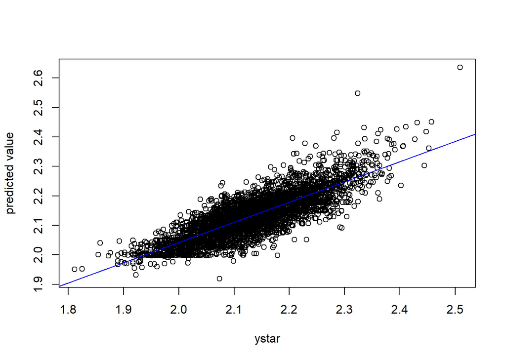

```r
reg<-lm(pred ~ ystar, data = test)
plot(test$ystar,test$pred,xlab="ystar", ylab="predicted value")
abline(reg, col="blue")
```

```r
summary(reg)
```

```
##
## Call:
## lm(formula = pred ~ ystar, data = test)
##
## Residuals:
##      Min       1Q   Median       3Q      Max
## -0.17352 -0.02637  0.00048  0.02572  0.28424
##
## Coefficients:
##             Estimate Std. Error t value Pr(>|t|)
## (Intercept) 0.670539   0.014815   45.26   <2e-16 ***
## ystar       0.685511   0.006949   98.65   <2e-16 ***
## ---
## Signif. codes:  0 '***' 0.001 '**' 0.01 '*' 0.05 '.' 0.1 ' ' 1
##
## Residual standard error: 0.04159 on 4321 degrees of freedom
## Multiple R-squared:  0.6925, Adjusted R-squared:  0.6924
## F-statistic:  9732 on 1 and 4321 DF,  p-value: < 2.2e-16
```

## Section 4: Logistic Regression Model

For our initial, “full” model, we will include the following variables:

Response:  
- `Seattle`: whether the home is in Seattle (1), or elsewhere in King County (0)

Predictors:  
- `waterfront`: whether the apartment was overlooking the waterfront (1) or not (0)  
- `price`: price of each home sold ($)  
- `sqft_lot`: square footage of the land space  
- `condition`: an index from 1 to 5 on the condition of the apartment  
- `bedrooms`: # of bedrooms*  
- `bathrooms`: # of bathrooms, where .5 accounts for a room with a toilet but no shower*  
- `view`: an index from 0 to 4 of how good the view of the property was**  
- `sqft_above`: the square footage of the interior housing space that is above ground level**,

where ** indicates a potential multicolinearity issue, and * indicates a potential interaction term.

Assumptions:  
- Observations are independent.  
- Response variable is a Bernoulli random variable, with: $P(y_i = 1) = \pi_i$ and $P(y_i = 0) = 1 - \pi_i$

#### Fit the initial FULL model

```r
train = subset(train, select = -c(id) )
```

```r
train$Seattle <- as.factor(train$Seattle)
train$waterfront <- as.factor(train$waterfront)
train$view <- as.factor(train$view)
train$condition <- as.factor(train$condition)
```

```r
initial <- glm(formula=Seattle ~ waterfront + price + sqft_lot + condition + bedrooms + bathrooms + sqft_above + view, family=binomial, data=train)
summary(initial)
```

```
##
## Call:
## glm(formula = Seattle ~ waterfront + price + sqft_lot + condition +
##     bedrooms + bathrooms + sqft_above + view, family = binomial,
##     data = train)
##
## Deviance Residuals:
##     Min       1Q   Median       3Q      Max
## -3.2145  -0.8114  -0.1620   0.7929   7.0728
##
## Coefficients:
##                        Estimate Std. Error z value Pr(>|z|)
## (Intercept)           4.436e+00  5.926e-01   7.485 7.14e-14 ***
## waterfrontWaterfront -1.181e+00  3.173e-01  -3.723 0.000197 ***
## price                 2.683e-06  8.293e-08  32.354  < 2e-16 ***
## sqft_lot             -1.725e-04  5.251e-06 -32.851  < 2e-16 ***
## condition2           -6.560e-01  6.268e-01  -1.047 0.295230
## condition3           -1.365e+00  5.885e-01  -2.320 0.020342 *
## condition4           -1.879e+00  5.887e-01  -3.191 0.001417 **
## condition5           -1.361e+00  5.914e-01  -2.302 0.021333 *
## bedrooms              1.640e-01  2.605e-02   6.295 3.07e-10 ***
## bathrooms            -5.789e-01  3.748e-02 -15.446  < 2e-16 ***
## sqft_above           -1.606e-03  4.673e-05 -34.364  < 2e-16 ***
## view1                 9.642e-01  1.579e-01   6.106 1.02e-09 ***
## view2                 1.076e+00  1.015e-01  10.594  < 2e-16 ***
## view3                 1.248e+00  1.429e-01   8.733  < 2e-16 ***
## view4                 1.631e+00  2.310e-01   7.060 1.67e-12 ***
## ---
## Signif. codes:  0 '***' 0.001 '**' 0.01 '*' 0.05 '.' 0.1 ' ' 1
##
## (Dispersion parameter for binomial family taken to be 1)
##
##     Null deviance: 23474  on 17289  degrees of freedom
## Residual deviance: 16762  on 17275  degrees of freedom
## AIC: 16792
##
## Number of Fisher Scoring iterations: 8
```

#### Stepwise

Stepwise Regression, starting with the intercept-only model

```r
# Intercept-only model
int_mod <- glm(Seattle~1, family='binomial', data=train)
```

```r
step(int_mod, scope=list(lower=int_mod, upper=initial), direction="both")
```

```
## Start:  AIC=23476.2
## Seattle ~ 1
```

```
##              Df Deviance   AIC
## + sqft_lot    1    20335 20339
## + sqft_above  1    20880 20884
## + bathrooms   1    22392 22396
## + bedrooms    1    22842 22846
## + condition   4    23297 23307
## + view        4    23336 23346
## <none>             23474 23476
## + price       1    23472 23476
## + waterfront  1    23473 23477
```

```
##
## Step:  AIC=20339.35
## Seattle ~ sqft_lot
```

```
##              Df Deviance   AIC
## + sqft_above  1    18845 18851
## + bathrooms   1    19459 19465
## + view        4    19893 19905
## + bedrooms    1    20050 20056
## + condition   4    20132 20144
## + price       1    20238 20244
## + waterfront  1    20272 20278
## <none>             20335 20339
## - sqft_lot    1    23474 23476
```

```
##
## Step:  AIC=18850.86
## Seattle ~ sqft_lot + sqft_above
```

```
##              Df Deviance   AIC
## + price       1    17343 17351
## + view        4    18098 18112
## + condition   4    18723 18737
## + waterfront  1    18751 18759
## + bathrooms   1    18818 18826
## + bedrooms    1    18841 18849
## <none>             18845 18851
## - sqft_above  1    20335 20339
## - sqft_lot    1    20880 20884
```

```
##
## Step:  AIC=17351.16
## Seattle ~ sqft_lot + sqft_above + price
```

```
##              Df Deviance   AIC
## + view        4    17145 17161
## + bathrooms   1    17183 17193
## + condition   4    17222 17238
## <none>             17343 17351
## + bedrooms    1    17343 17353
## + waterfront  1    17343 17353
## - price       1    18845 18851
## - sqft_lot    1    19460 19466
## - sqft_above  1    20238 20244
```

```
##
## Step:  AIC=17160.94
## Seattle ~ sqft_lot + sqft_above + price + view
```

```
##              Df Deviance   AIC
## + bathrooms   1    16962 16980
## + condition   4    17022 17046
## + waterfront  1    17133 17151
## <none>             17145 17161
## + bedrooms    1    17144 17162
## - view        4    17343 17351
## - price       1    18098 18112
## - sqft_lot    1    19373 19387
## - sqft_above  1    19890 19904
```

```
##
## Step:  AIC=16980.25
## Seattle ~ sqft_lot + sqft_above + price + view + bathrooms
```

```
##              Df Deviance   AIC
## + condition   4    16818 16844
## + bedrooms    1    16934 16954
## + waterfront  1    16949 16969
## <none>             16962 16980
## - bathrooms   1    17145 17161
## - view        4    17183 17193
## - price       1    18027 18043
## - sqft_above  1    18301 18317
## - sqft_lot    1    19341 19357
```

```
##
## Step:  AIC=16844.22
## Seattle ~ sqft_lot + sqft_above + price + view + bathrooms +
##     condition
```

```
##              Df Deviance   AIC
## + bedrooms    1    16776 16804
## + waterfront  1    16803 16831
## <none>             16818 16844
## - condition   4    16962 16980
## - bathrooms   1    17022 17046
## - view        4    17041 17059
## - price       1    17899 17923
## - sqft_above  1    18177 18201
## - sqft_lot    1    19037 19061
```

```
##
## Step:  AIC=16804.06
## Seattle ~ sqft_lot + sqft_above + price + view + bathrooms +
##     condition + bedrooms
```

```
##              Df Deviance   AIC
## + waterfront  1    16762 16792
## <none>             16776 16804
## - bedrooms    1    16818 16844
## - condition   4    16934 16954
## - view        4    17006 17026
## - bathrooms   1    17019 17045
## - price       1    17868 17894
## - sqft_above  1    18173 18199
## - sqft_lot    1    19032 19058
```

```
##
## Step:  AIC=16792.34
## Seattle ~ sqft_lot + sqft_above + price + view + bathrooms +
##     condition + bedrooms + waterfront
```

```
##              Df Deviance   AIC
## <none>             16762 16792
## - waterfront  1    16776 16804
## - bedrooms    1    16803 16831
## - condition   4    16923 16945
## - view        4    17006 17028
## - bathrooms   1    17006 17034
## - price       1    17868 17896
## - sqft_above  1    18170 18198
## - sqft_lot    1    18979 19007
```

```
##
## Call:  glm(formula = Seattle ~ sqft_lot + sqft_above + price + view +
##     bathrooms + condition + bedrooms + waterfront, family = "binomial",
##     data = train)
##
## Coefficients:
##          (Intercept)              sqft_lot            sqft_above
##            4.436e+00            -1.725e-04            -1.606e-03
##                price                 view1                 view2
##            2.683e-06             9.642e-01             1.076e+00
##                view3                 view4             bathrooms
##            1.248e+00             1.631e+00            -5.789e-01
##           condition2            condition3            condition4
##           -6.560e-01            -1.365e+00            -1.879e+00
##           condition5              bedrooms  waterfrontWaterfront
##           -1.361e+00             1.640e-01            -1.181e+00
##
## Degrees of Freedom: 17289 Total (i.e. Null);  17275 Residual
## Null Deviance:       23470
## Residual Deviance: 16760     AIC: 16790
```

According to Stepwise Regression, all of the predictors we initially chose for our model were included to create this model with the best AIC.

Our estimated regression equation for this logistic regression model: $log(\frac{\hat\pi}{1-\hat\pi}) = 4.436 - 1.181x_1 + 0.000002683x_2 - 0.0001725x_3 - 0.6560x_4 - 1.365x_5 - 1.879x_6 - 1.361x_7 + 0.1640x_8 - 0.5789x_9 - 0.001606x_{10} + 0.9642x_{11} + 1.076x_{12} + 1.248x_{13} + 1.631x_{14}$

where,  
$x_1$ = 1 for indicating a `waterfront` view, 0 otherwise  
$x_2$: `price`  
$x_3$: `sqft_lot`  
$x_4$ = 1 for a `condition` of 2, 0 otherwise  
$x_5$ = 1 for a `condition` of 3, 0 otherwise  
$x_6$ = 1 for a `condition` of 4, 0 otherwise $x_7$ = 1 for a `condition` of 5, 0 otherwise $x_8$: `bedrooms`  
$x_9$: `bathrooms`  
$x_{10}$: `sqft_above`  
$x_{11}$ = 1 for a `view` index of 1, 0 otherwise  
$x_{12}$ = 1 for a `view` index of 2, 0 otherwise  
$x_{13}$ = 1 for a `view` index of 3, 0 otherwise  
$x_{14}$ = 1 for a `view` index of 4, 0 otherwise

Base Cases:  
- For a `condition` of 1: $x_4$ = $x_5$ = $x_6$ = $x_7$ = 0  
- For a `view` index of 0: $x_{11}$ = $x_{12}$ = $x_{13}$ = $x_{14}$ = 0

Wald Test: `condition`

P-Values for…  
$\beta_4$: condition2 = 0.295230  
$\beta_5$: condition3 = 0.020342  
$\beta_6$: condition4 = 0.001417  
$\beta_7$: condition5 = 0.021333

```r
# Put condition back to quantitative
train$condition <- as.numeric(train$condition)
```

```r
# Re-fit the same initial model, but with the quantitative condition
initial2 <- glm(formula=Seattle ~ waterfront + price + sqft_lot + condition + bedrooms + bathrooms + sqft_above + view, family=binomial, data=train)
summary(initial2)
```

```
##
## Call:
## glm(formula = Seattle ~ waterfront + price + sqft_lot + condition +
##     bedrooms + bathrooms + sqft_above + view, family = binomial,
##     data = train)
##
## Deviance Residuals:
##     Min       1Q   Median       3Q      Max
## -3.2018  -0.8307  -0.1586   0.8014   7.1352
##
## Coefficients:
##                        Estimate Std. Error z value Pr(>|z|)
## (Intercept)           3.585e+00  1.308e-01  27.404  < 2e-16 ***
## waterfrontWaterfront -1.130e+00  3.176e-01  -3.559 0.000372 ***
## price                 2.685e-06  8.265e-08  32.491  < 2e-16 ***
## sqft_lot             -1.760e-04  5.238e-06 -33.597  < 2e-16 ***
## condition            -1.910e-01  2.926e-02  -6.527 6.73e-11 ***
## bedrooms              1.531e-01  2.588e-02   5.916 3.29e-09 ***
## bathrooms            -5.484e-01  3.704e-02 -14.804  < 2e-16 ***
## sqft_above           -1.599e-03  4.654e-05 -34.370  < 2e-16 ***
## view1                 9.537e-01  1.572e-01   6.066 1.31e-09 ***
## view2                 1.072e+00  1.010e-01  10.606  < 2e-16 ***
## view3                 1.218e+00  1.431e-01   8.517  < 2e-16 ***
## view4                 1.604e+00  2.312e-01   6.935 4.07e-12 ***
## ---
## Signif. codes:  0 '***' 0.001 '**' 0.01 '*' 0.05 '.' 0.1 ' ' 1
##
## (Dispersion parameter for binomial family taken to be 1)
##
##     Null deviance: 23474  on 17289  degrees of freedom
## Residual deviance: 16880  on 17278  degrees of freedom
## AIC: 16904
##
## Number of Fisher Scoring iterations: 8
```

Our estimated regression equation for this logistic regression model: $log(\frac{\hat\pi}{1-\hat\pi}) = 3.585 - 1.130x_1 + 0.000002685x_2 - 0.0001760x_3 - 0.1910x_4 + 0.1531x_5 - 0.5484x_6 - 0.001599x_7 + 0.9537x_8 + 1.072x_9 + 1.218x_{10} + 1.604x_{11}$

where,  
$x_1$ = 1 for indicating a `waterfront` view, 0 otherwise  
$x_2$: `price`  
$x_3$: `sqft_lot`  
$x_4$: `condition` $x_5$: `bedrooms`  
$x_6$: `bathrooms`  
$x_7$: `sqft_above`  
$x_8$ = 1 for a `view` index of 1, 0 otherwise  
$x_9$ = 1 for a `view` index of 2, 0 otherwise  
$x_{10}$ = 1 for a `view` index of 3, 0 otherwise  
$x_{11}$ = 1 for a `view` index of 4, 0 otherwise

#### Likelihood Ratio Test

$H_0$: $\beta_{8} = \beta_{9} = \beta_{10} = \beta_{11} = 0$  
$H_a$: at least one is $\neq$ 0.

Fit the reduced model:

```r
reduced <- glm(formula=Seattle ~ waterfront + price + sqft_lot + condition + bedrooms + bathrooms + sqft_above, family=binomial, data=train)
summary(reduced)
```

```
##
## Call:
## glm(formula = Seattle ~ waterfront + price + sqft_lot + condition +
##     bedrooms + bathrooms + sqft_above, family = binomial, data = train)
##
## Deviance Residuals:
##     Min       1Q   Median       3Q      Max
## -3.1266  -0.8398  -0.1733   0.8124   6.9318
##
## Coefficients:
##                        Estimate Std. Error z value Pr(>|z|)
## (Intercept)           3.445e+00  1.293e-01  26.648  < 2e-16 ***
## waterfrontWaterfront -1.042e-01  2.595e-01  -0.401    0.688
## price                 2.990e-06  8.043e-08  37.175  < 2e-16 ***
## sqft_lot             -1.662e-04  5.105e-06 -32.551  < 2e-16 ***
## condition            -1.859e-01  2.900e-02  -6.409 1.47e-10 ***
## bedrooms              1.402e-01  2.566e-02   5.465 4.64e-08 ***
## bathrooms            -5.070e-01  3.664e-02 -13.837  < 2e-16 ***
## sqft_above           -1.631e-03  4.612e-05 -35.354  < 2e-16 ***
## ---
## Signif. codes:  0 '***' 0.001 '**' 0.01 '*' 0.05 '.' 0.1 ' ' 1
##
## (Dispersion parameter for binomial family taken to be 1)
##
##     Null deviance: 23474  on 17289  degrees of freedom
## Residual deviance: 17119  on 17282  degrees of freedom
## AIC: 17135
##
## Number of Fisher Scoring iterations: 8
```

Conduct the Likelihood Ratio Test:

```r
# Calculate ∆G2 test statistic
test_stat <-reduced$null.deviance - initial2$deviance
print(paste('∆G2 test statistic:', test_stat))
```

```
## [1] "∆G2 test statistic: 6593.96061191045"
```

```r
# P-Value
pval <- 1-pchisq(test_stat, 7)
print(paste('P-Value:', pval))
```

```
## [1] "P-Value: 0"
```

Based on these analysis’, we will carry on with the full model.

#### Interpret Coefficients

Our estimated regression equation for this logistic regression model: $log(\frac{\hat\pi}{1-\hat\pi}) = 3.585 - 1.130x_1 + 0.000002685x_2 - 0.0001760x_3 - 0.1910x_4 + 0.1531x_5 - 0.5484x_6 - 0.001599x_7 + 0.9537x_8 + 1.072x_9 + 1.218x_{10} + 1.604x_{11}$

where,  
$x_1$ = 1 for indicating a `waterfront` view, 0 otherwise  
$x_2$: `price`  
$x_3$: `sqft_lot`  
$x_4$: `condition` $x_5$: `bedrooms`  
$x_6$: `bathrooms`  
$x_7$: `sqft_above`  
$x_8$ = 1 for a `view` index of 1, 0 otherwise  
$x_9$ = 1 for a `view` index of 2, 0 otherwise  
$x_{10}$ = 1 for a `view` index of 3, 0 otherwise  
$x_{11}$ = 1 for a `view` index of 4, 0 otherwise

#### ROC curve

```r
# Change appropriate test variables
test$Seattle <- as.factor(test$Seattle)
test$waterfront <- as.factor(test$waterfront)
test$view <- as.factor(test$view)
```

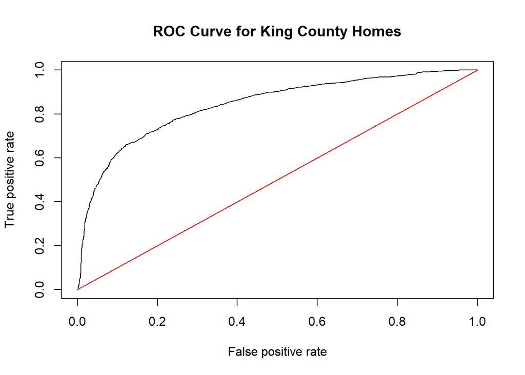

```r
preds<-predict(initial2, newdata=test, type="response")
rates<-prediction(preds, test$Seattle)
roc_result<-performance(rates, measure="tpr", x.measure="fpr")
plot(roc_result, main="ROC Curve for King County Homes")
lines(x = c(0,1), y = c(0,1), col="red")
```

Our ROC curve falls above the diagonal red line, thus performs better than random guessing.

#### AUC

Compute the AUC

```r
auc<-performance(rates, measure = "auc")
auc@y.values
```

```
## [[1]]
## [1] 0.8420609
```

The AUC of 0.8420609 means the logistic regression performs better than random guessing.

#### Confusion Matrix

We are not necessarily too worried about false positives over false negatives or vice versa, thus will begin with a cutoff of 0.5.

```r
table(test$Seattle, preds>0.5)
```

```
##
##                            FALSE TRUE
##   Elsewhere in King County  2043  489
##   Seattle                    494 1297
```

**Calculate**:  
Overall Error Rate:

```r
# Overall Error Rate
(489 + 494)/(2043 + 489 + 494 + 1297)
```

```
## [1] 0.2273884
```

Accuracy:

```r
# Accuracy
1 - 0.2273884
```

```
## [1] 0.7726116
```

False Positive Rate:

```r
# False Positive Rate
489/(489 + 2043)
```

```
## [1] 0.193128
```

False Negative Rate:

```r
# False Negative Rate
494/(494 + 1297)
```

```
## [1] 0.2758236
```

Sensitivity:

```r
# Sensitivity
1297/(1297 + 494)
```

```
## [1] 0.7241764
```

Specificity:

```r
# Specificity
2043/(2043 + 489)
```

```
## [1] 0.806872
```

Comparing our False Positive Rate (of 0.193128) and the ROC curve, it is apparant that the logistic regression at the threshold cutoff of 0.5 is significantly better than random guessing.

Create a Density Plot of the predicted probabilities of a home being in Seattle in the test dat

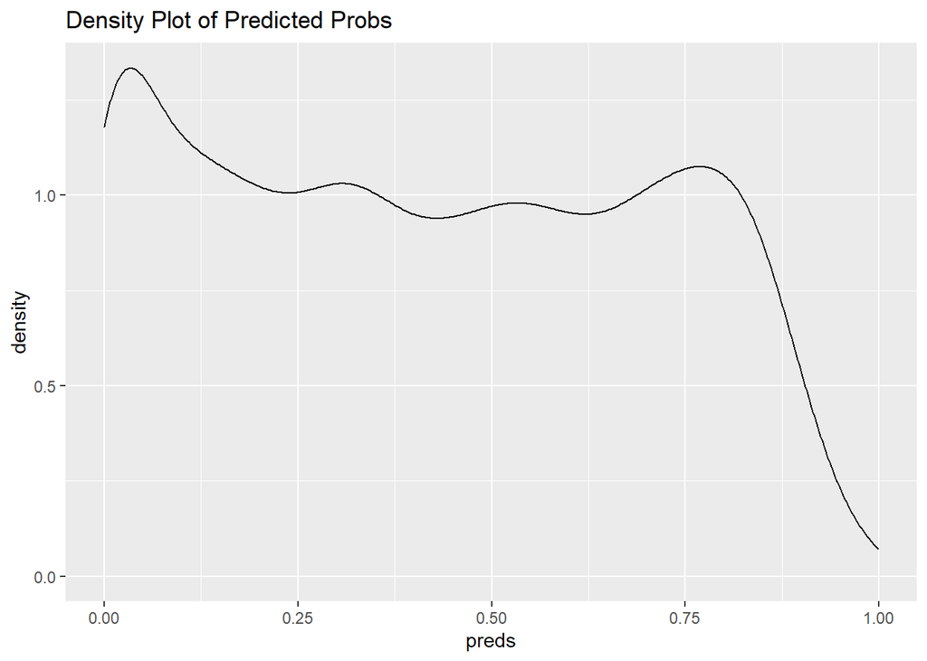

```r
ggplot(test, aes(x=preds))+
  geom_density()+
  labs(title="Density Plot of Predicted Probs")
```

Looks good.

```r
train %>%
  filter(Seattle == 1) %>%
  summarise(mean(sqft_lot))
```

```
##   mean(sqft_lot)
## 1            NaN
```

#### Odds, Log Odds, and Prediction of a Specific Home

For sake of example, our client is looking for their dream home. Ideally, wants to live in Seattle. Given her preferences, what are the log odds the house she’s looking for is in Seattle? She wants:

- A `waterfront` view
- An ideal `price` of $660,000
- At least a small yard for her dog to play in, so an approximate `sqft_lot` size of 2,000 square feet
- A home in good (4) `condition`
- 2 `bedrooms` - one for her, one for guests
- 2 full `bathrooms`
- Roughly 1,000 square feet above ground (`sqft_above`)
- An excellent (4) `view`

```r
client<-data.frame(waterfront='Waterfront',
                   price=660000,
                   sqft_lot=2000,
                   condition=4,
                   bedrooms=2,
                   bathrooms=2,
                   sqft_above=1000,
                   view='4')
predict(initial2, client)
```

```
##        1
## 2.324848
```

The log odds of the home she’s looking for being in Seattle is 2.324848.

```r
# Convert to odds
odds<-exp(predict(initial2, client))
#odds

paste('Log odds:', 2.324848)
```

```
## [1] "Log odds: 2.324848"
```

```r
paste('Odds:', 10.22512)
```

```
## [1] "Odds: 10.22512"
```

```r
paste('Probability:', 0.9109141)
```

```
## [1] "Probability: 0.9109141"
```

```r
# Convert odds to probability
prob<-odds/(1+odds)
prob
```

```
##         1
## 0.9109141
```

The corresponding odds is 10.22512, and the corresponding probability is 0.9109141!

**OUR MODEL IS initial2**

```r
# Interpreting coefficients
exp(-1.130)
```

```
## [1] 0.3230333
```

```r
# Interpreting coefficients
prob<-1.46/(1+1.46)
prob
```

```
## [1] 0.5934959
```